# Rapport statistique sous RStudio

#### Quelle est l’évolution du nombre de naissance pendant le mois de Décembre de 2000 à 2014?

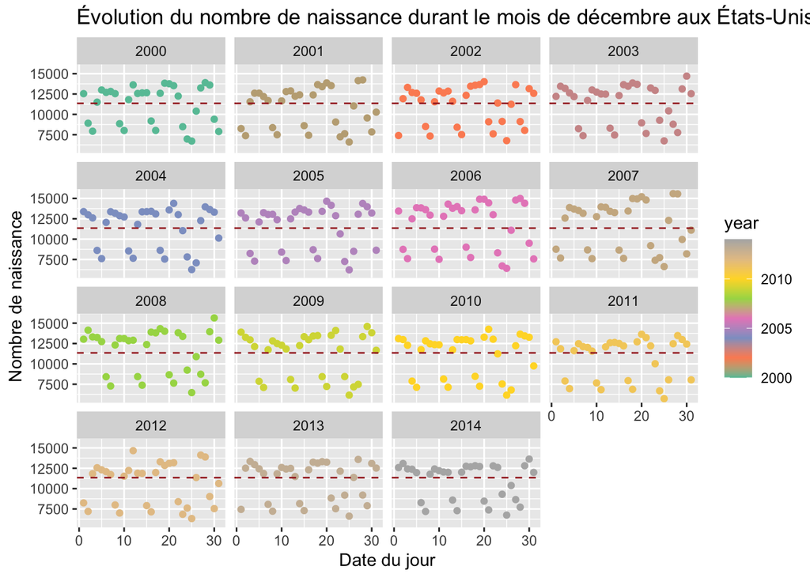

```r
us_births %>%
  filter(month == 12) %>%
  ggplot(aes(x=date_of_month,y=births, color=year))+
  geom_point() +
  scale_color_gradientn(colours = RColorBrewer::brewer.pal(12, "Set2")) ->d
d +
 facet_wrap(~year)+
  geom_hline(yintercept=mean(us_births$births), linetype="dashed",color="brown", size=0.5)+
  labs(y = "Nombre de naissance",x= "Date du jour", title = "Évolution du nombre de naissance durant le mois de décembre aux États-Unis des années 2000 à 2014")
```

On constate que les naissances du mois de décembre sont plutôt similaires au fil des années et que de manière général la plupart des données se situent au dessus de la moyenne de naissance par jour. Néanmoins on remarque qu’à partir de 2011 les données sont moins élevés qu’au début des années 2000.

#### Quel est le jour de la semaine où il y a le plus de naissance?

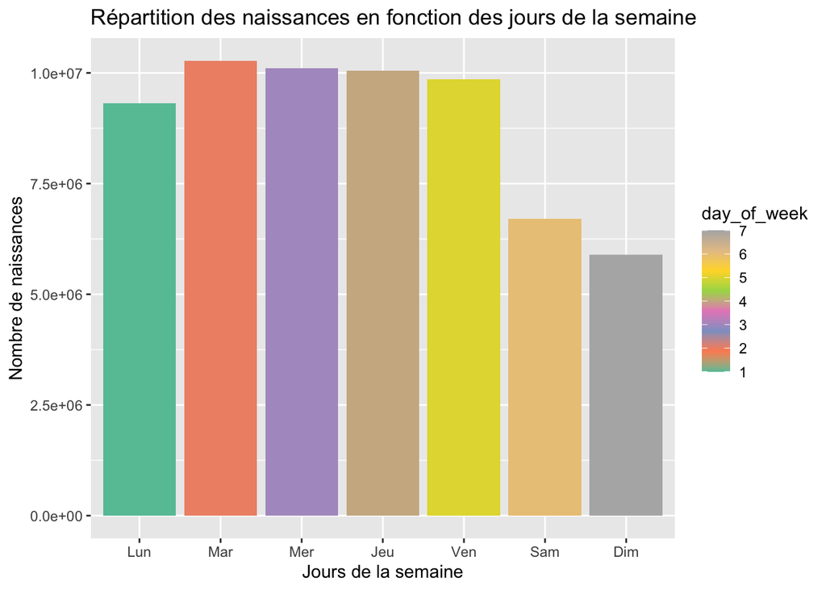

```r
us_births %>%
  group_by(day_of_week) %>%
  ggplot(aes(y= births , x= day_of_week, fill= day_of_week))+
  geom_col()+
  scale_fill_gradientn(colours = RColorBrewer::brewer.pal(12, "Set2"))+
  scale_x_discrete(limit = c("1","2","3","4","5","6","7"),
                    labels = c("Lun","Mar","Mer","Jeu","Ven","Sam","Dim"))+
  labs(title="Répartition des naissances en fonction des jours de la semaine",
       x="Jours de la semaine",
       y="Nombre de naissances")
```

On observe qu’en moyenne le jour de la semaine où il y a le plus de naissance c’est le **mardi**. À l’inverse, le jour où il y a le moins de naissance c’est le **dimanche**.  
De manière plus général, on constate qu’il y a plus de naissance en semaine qu’en week-end.